# Clase 8: Análisis de Correspondencias Simple

Práctico AID 2022

03/06/2022

# Introducción

El análisis de corrrespondencias es una técnica descriptiva/exploratoria diseñada para analizar correspondencias entre filas y columnas de una tabla múltiple. Constituye una extensión de la Análisis de Componentes Principales (PCA) para datos categóricos, y permite la exploración de su estructura.

El objetivo del análisis de correspondencias es la representación de las entradas de la tabla de frecuencias relativas en términos de distancias entre filas y columnas individuales, en un espacio de baja dimensión (escalado multidimensional).

Asume que las variables son nominales y permite describir las relaciones entre las categorías de cada variable, así como la relación entre las variables. Además, el análisis de correspondencias se puede utilizar para analizar cualquier tabla de medidas de correspondencia que sean positivas.

## Cargo librerías

```r
library(FactoMineR)
library(factoextra)
library(RColorBrewer)
library(ggplot2)
library(ggmosaic)
library(dplyr)
library(tidyverse)
library(DescTools)
library(corrplot)
library(gplots)
library(FactoClass)
library(rgl)
library(logmult)
```

## Estilo general para los gráficos

```r
theme <- theme(text = element_text(size=10),
               plot.title = element_text(size = 12, face = "bold.italic", hjust = 0.5),
               axis.title.x = element_text(size = 10, face="bold", colour='black'),
               axis.title.y = element_text(size = 10, face="bold"),
               panel.border = element_blank(),
               panel.grid.major = element_blank(),
               panel.grid.minor = element_blank(),
               legend.title = element_text(face="bold"))
```

## Intuición gráfica

*(Ejemplo M.Greenacre) Relación entre destinos de un viaje y cantidad de días festivos*

```r
# Creación de BD
noruega <- c(6,1,11)
canada <- c(1,3,11)
grecia <- c(4,25,0)
francia <- c(2,2,20)
df_viaje <-  rbind(noruega,canada,grecia,francia)
colnames(df_viaje) <- c("Festivos","Media Jornada","J. completa")
rownames(df_viaje) <- c("noruega","canada","grecia","francia")
df_viaje
```

```
##         Festivos Media Jornada J. completa
## noruega        6             1          11
## canada         1             3          11
## grecia         4            25           0
## francia        2             2          20
```

Cálculo de perfiles fila

```r
# Perfiles fila (la suma de las frecuencias de cada fila da 1)
df_viaje_fila <-  round(prop.table(df_viaje,1),3)
df_viaje_fila
```

```
##         Festivos Media Jornada J. completa
## noruega    0.333         0.056       0.611
## canada     0.067         0.200       0.733
## grecia     0.138         0.862       0.000
## francia    0.083         0.083       0.833
```

Representación de perfiles fila sobre coordenadas de columnas Distancias euclídeas sobre plano

```r
open3d()
```

```
## glX
##   1
```

```r
bg3d(color = "white")
rgl.lines(c(0,1.2),c(0,0),c(0,0), color='lightgray')
rgl.lines(c(0,0),c(0,1.2),c(0,0), color='lightgray')
rgl.lines(c(0,0),c(0,0),c(0,1.2), color='lightgray')

rgl.lines(c(0,0),c(0,1),c(1,0), size=2, color='steelblue2')
rgl.lines(c(0,1),c(1,0),c(0,0), size=2, color='steelblue2')
rgl.lines(c(0,1),c(0,0),c(1,0), size=2, color='steelblue2')

rgl.points(df_viaje_fila[,3],df_viaje_fila[,1],df_viaje_fila[,2], size=4, color='darkblue')

rgl.texts(df_viaje_fila[,3],df_viaje_fila[,1],df_viaje_fila[,2], text=rownames(df_viaje_fila), color='darkblue', cex=.5)

rgl.texts(matrix(c( 0,0,1.25, 1.15,0,0, 0,1.15,0), byrow = T, ncol = 3), text=colnames(df_viaje_fila), color='steelblue2')

rglwidget()
```

[interactive chart not shown]

Explicación gráfica de Inercia

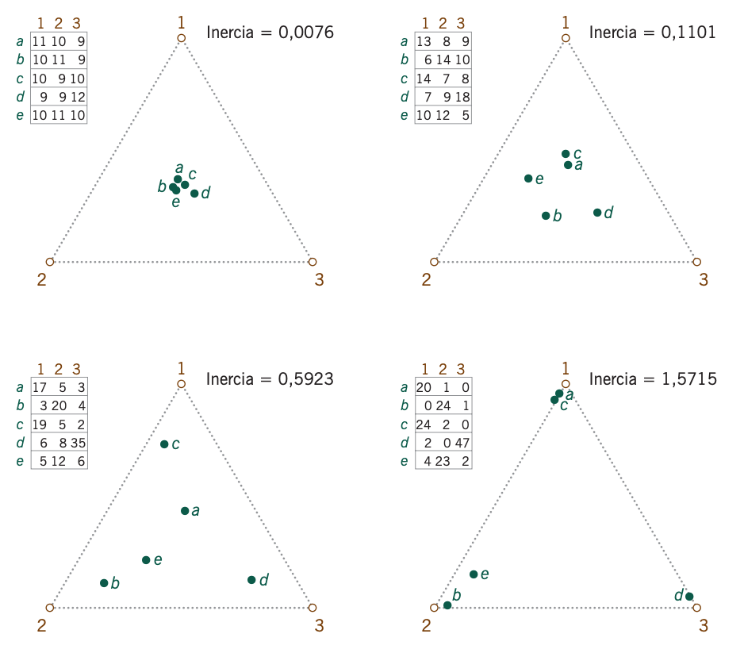

*Foto tomada de https://www.fbbva.es/wp-content/uploads/2017/05/dat/DE_2008_practica_analisis_correspondencias.pdf, página 50*

*A mayores valores de inercia (> chi-cuadrado), mayor alejamiento de la independencia y del perfil medio*

Representación de perfiles fila sobre coordenadas de columnas Distancias chi-cuadrado

```r
open3d()
```

```
## glX
##   2
```

```r
bg3d(color = "white")
table.pro <- df_viaje/apply(df_viaje,1,sum)
table.x   <- 1-table.pro[,1]-table.pro[,3]/2
table.y   <- table.pro[,3]*sqrt(3)/2

table.rowsum <- apply(df_viaje, 1, sum)
table.colsum <- apply(df_viaje, 2, sum)
table.sum    <- sum(df_viaje)
table.exp    <- table.rowsum%o%table.colsum/table.sum
chi2         <- sum((df_viaje-table.exp)^2/table.exp)

# distancias chi-cuadrado de perfiles fila al perfil fila medio
table.colmass <- table.colsum/table.sum
sqrt(apply((t(table.pro)-table.colmass)^2/table.colmass, 2, sum))
```

```
##   noruega    canada    grecia   francia
## 0.7129532 0.4914606 1.0897409 0.6979707
```

```r
# todas las distancias chi-cuadrado
tablec.pro <- rbind(table.pro,table.colmass)
rownames(tablec.pro)[5] <- "ave"
dist(sweep(tablec.pro, 2, sqrt(table.colmass), FUN = "/"))
```

```
##           noruega    canada    grecia   francia
## canada  0.7475938
## grecia  1.6798211 1.5332280
## francia 0.7188318 0.2450993 1.7674924
## ave     0.7129532 0.4914606 1.0897409 0.6979707
```

```r
# Gráfico de distancias chi-cuadrado
table.wt <- sqrt(table.colmass)

rgl.lines(c(0,1.1/table.wt[2]), c(0,0), c(0,0), color='lightgray')
rgl.lines(c(0,0), c(0,1.1/table.wt[3]), c(0,0), color='lightgray')
rgl.lines(c(0,0), c(0,0), c(0,1.1/table.wt[1]), color='lightgray')

rgl.lines(c(0,0), c(0,1/table.wt[3]), c(1/table.wt[1],0), size = 2, color='red')
rgl.lines(c(0,1/table.wt[2]), c(1/table.wt[3],0), c(0,0), size = 2, color='red')
rgl.lines(c(0,1/table.wt[2]), c(0,0), c(1/table.wt[1],0), size = 2, color='red')

table.chi <- t(t(table.pro)/table.wt)

rgl.points(table.chi[,2],table.chi[,3],table.chi[,1], size=4, color='darkred')

rgl.texts(table.chi[,2], table.chi[,3], table.chi[,1], text = rownames(df_viaje), color='darkred', cex=0.5)
rgl.texts(matrix(c( 0,0,1.15/table.wt[2], 1.15/table.wt[3],0,0, 0,1.15/table.wt[1],0),
          byrow = T, ncol = 3), text = colnames(df_viaje), color='darkred')
rglwidget()
```

[interactive chart not shown]

# Ejemplos

## 1) Ejemplo 1

### Creo datos

*Relación de grado de atención de niños según el nivel SC de sus padres*

```r
# Creación de BD
atento  <- c(64,57, 57, 72, 36 ,21)
leve    <- c(94,94,105,141, 97 ,51)
moderado <- c(58,54, 65, 77, 54 ,34)
disperso <- c(46,40, 60, 94, 78 ,51)
base <-  rbind(atento,leve,moderado,disperso)
colnames(base) <- c("A","B","C","D","E","F")
rownames(base) <- c("Atento","Sínt.leves","Sínt.moderados","Disperso")
base
```

```
##                 A  B   C   D  E  F
## Atento         64 57  57  72 36 21
## Sínt.leves     94 94 105 141 97 51
## Sínt.moderados 58 54  65  77 54 34
## Disperso       46 40  60  94 78 51
```

### Test de independencia Chi cuadrado

```r
# Test de independencia Chi-cuadrado
chisq.test(base)
```

```
##
##  Pearson's Chi-squared test
##
## data:  base
## X-squared = 34.703, df = 15, p-value = 0.00271
```

Representación gráfica de los resultados (valores absolutos)

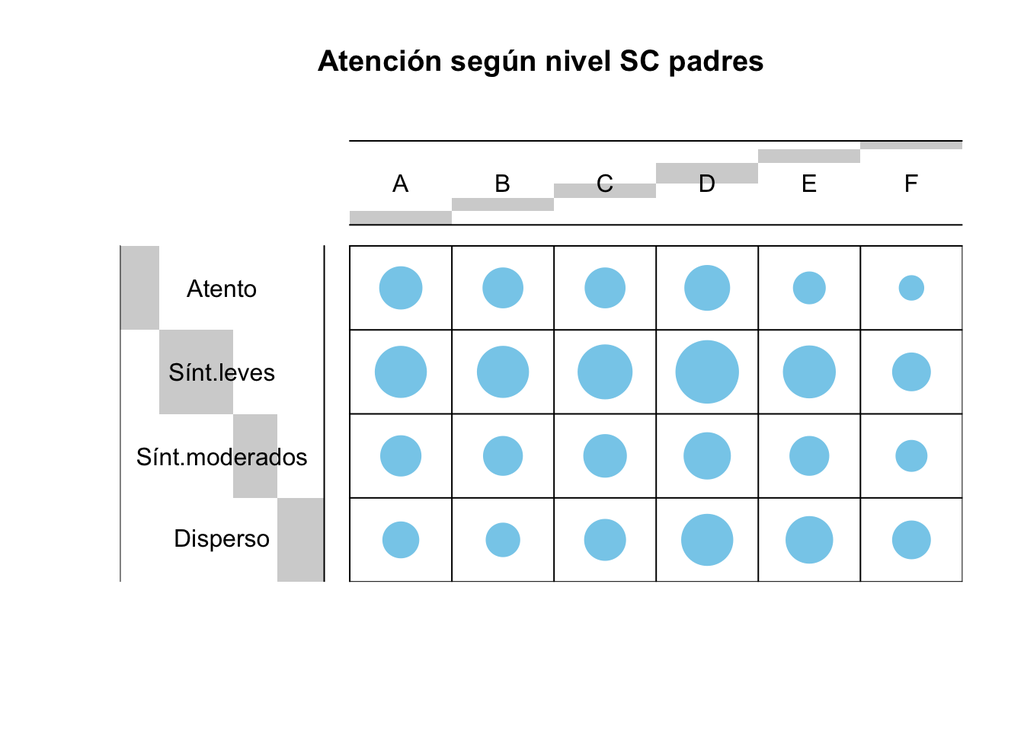

```r
balloonplot(t(as.table(as.matrix(base))), main ="Atención según nivel SC padres", xlab ="", ylab="",
            label = FALSE, show.margins = FALSE)
```

Gráfico de mosaico

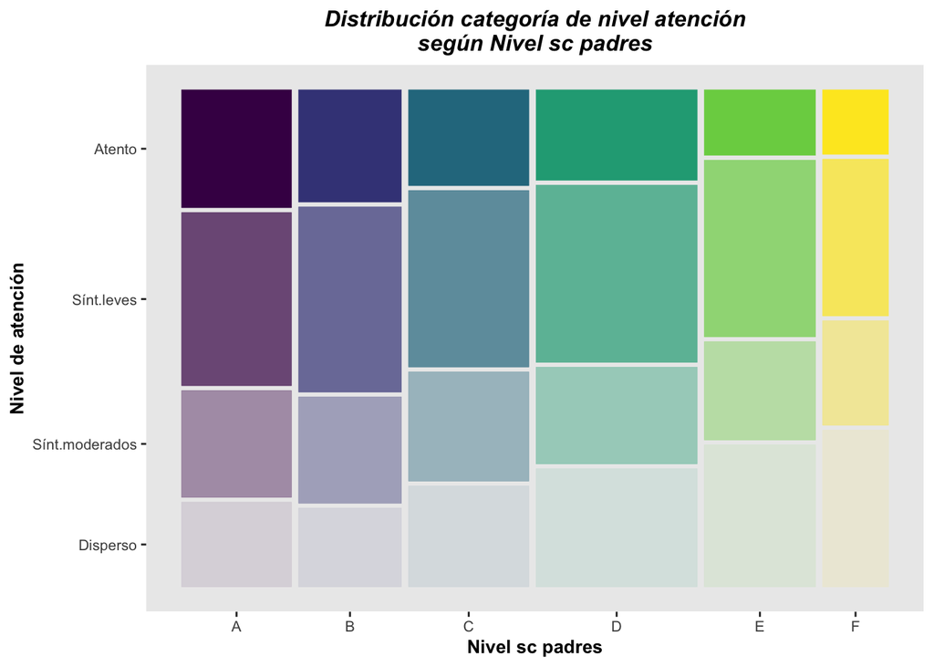

```r
#mosaicplot(base, col=brewer.pal(10,"Paired"), main="Distribución categoría de nivel atención\nsegún Nivel sc padres")

df_base <- data.frame(base)
df_base$atencion <- rownames(df_base)
df_base <- df_base %>% pivot_longer(!atencion, names_to = "Variable", values_to = "valor")
df_base <- as.data.frame(lapply(df_base, rep, df_base$valor))
df_base$atencion <- factor(df_base$atencion, levels= c('Disperso','Sínt.moderados', 'Sínt.leves','Atento'))

ggplot(data=df_base) +
  geom_mosaic(aes(x = product(atencion, Variable),
                  fill = Variable, alpha=atencion)) + theme +
  labs(title = 'Distribución categoría de nivel atención\nsegún Nivel sc padres',
              y = 'Nivel de atención', x = 'Nivel sc padres') +
  scale_fill_viridis_d() +
  theme(legend.position = 'none')
```

### Análisis de perfiles

Perfiles Fila

```r
# Perfiles fila (frecuencias de A/B/C... condicionales a cada categoría de atención)
bd_fila <-round(prop.table(base,1),3)
bd_fila
```

```
##                    A     B     C     D     E     F
## Atento         0.208 0.186 0.186 0.235 0.117 0.068
## Sínt.leves     0.162 0.162 0.180 0.242 0.167 0.088
## Sínt.moderados 0.170 0.158 0.190 0.225 0.158 0.099
## Disperso       0.125 0.108 0.163 0.255 0.211 0.138
```

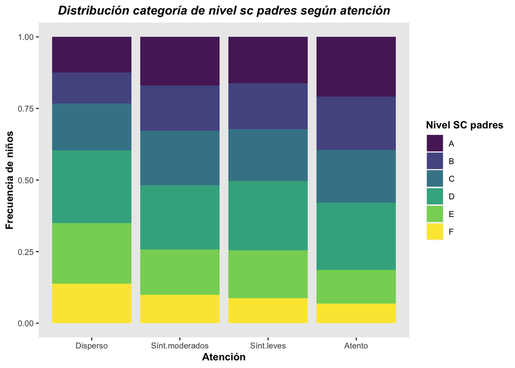

```r
ggplot(data=df_base, aes(x = atencion, fill= Variable))+geom_bar(position='fill', alpha=0.9)+theme+
  labs(title = 'Distribución categoría de nivel sc padres según atención',
              y = 'Frecuencia de niños', x = 'Atención') +
  scale_fill_viridis_d(name='Nivel SC padres')
```

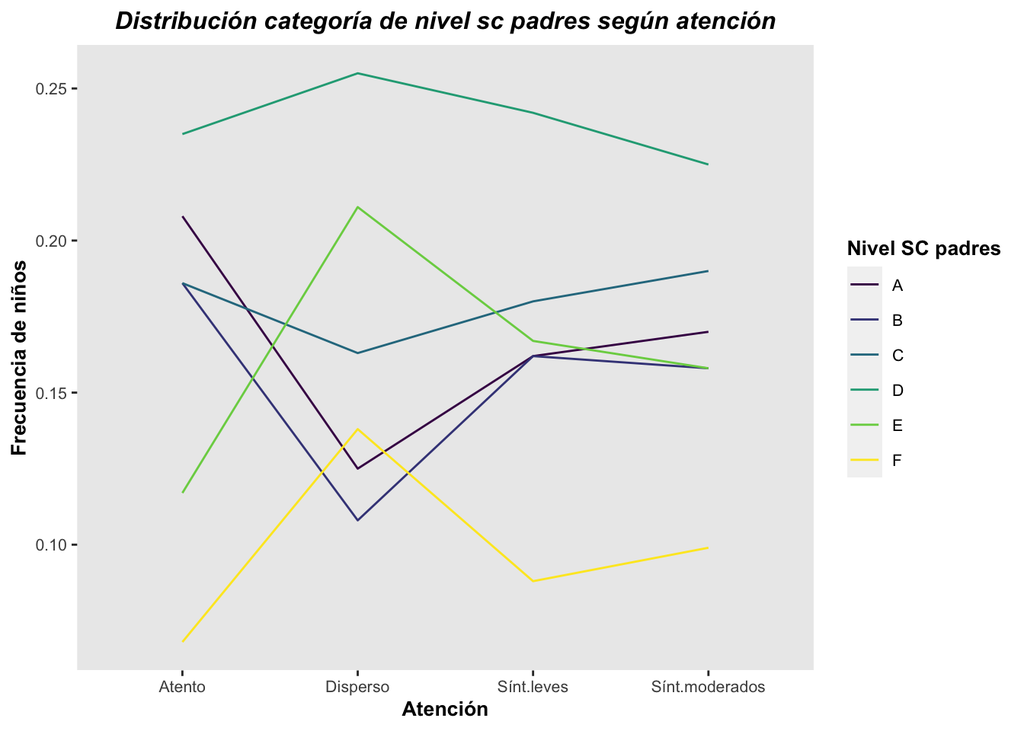

```r
bd_fila <- as.data.frame(bd_fila)
bd_fila$atencion <- rownames(bd_fila)
bd_fila <- bd_fila %>% pivot_longer(!atencion, names_to = "Variable", values_to = "valor")

ggplot(data=bd_fila, aes(y = valor, x= atencion, color=Variable))+geom_line(aes(group = Variable))+theme+
  labs(title = 'Distribución categoría de nivel sc padres según atención',
              y = 'Frecuencia de niños', x = 'Atención') +
  scale_color_viridis_d(name='Nivel SC padres')
```

```r
#plotct (base,"row",col=brewer.pal(10,"Paired"))# -> equivalente!
```

Perfiles Columna

```r
# Perfiles columna (frecuencias de niveles de atención, condicional a cada columna (categoría SC padres))
bd_col <- round(prop.table(base,2),3)
bd_col
```

```
##                    A     B     C     D     E     F
## Atento         0.244 0.233 0.199 0.188 0.136 0.134
## Sínt.leves     0.359 0.384 0.366 0.367 0.366 0.325
## Sínt.moderados 0.221 0.220 0.226 0.201 0.204 0.217
## Disperso       0.176 0.163 0.209 0.245 0.294 0.325
```

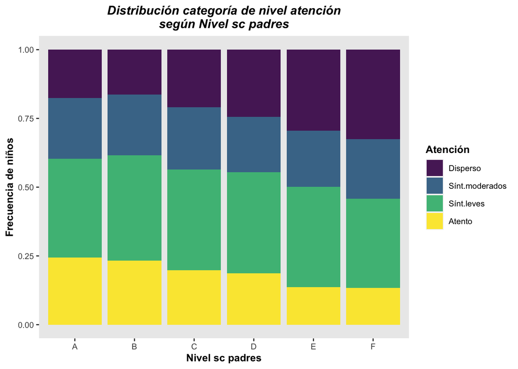

```r
ggplot(data=df_base, aes(x = Variable, fill= atencion))+geom_bar(position='fill', alpha=0.9)+theme+
  labs(title = 'Distribución categoría de nivel atención\nsegún Nivel sc padres',
              y = 'Frecuencia de niños', x = 'Nivel sc padres') +
  scale_fill_viridis_d(name='Atención')
```

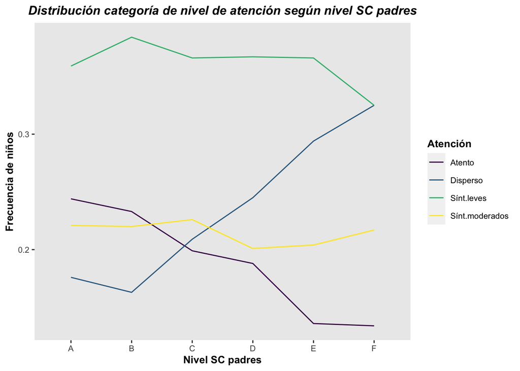

```r
bd_col <- as.data.frame(bd_col)
bd_col$atencion <- rownames(bd_col)
bd_col <- bd_col %>% pivot_longer(!atencion, names_to = "Variable", values_to = "valor")

ggplot(data=bd_col, aes(y = valor, x= Variable, color=atencion))+geom_line(aes(group = atencion))+theme+
  labs(title = 'Distribución categoría de nivel de atención según nivel SC padres',
              y = 'Frecuencia de niños', x = 'Nivel SC padres') +
  scale_color_viridis_d(name='Atención')
```

### Análisis de correspondencia simple

```r
atencion.ac = CA(base,graph=FALSE) # Realiza el analisis de correspondencias
get_ca_row(atencion.ac) # Muestra lo que se guarda de las filas
```

```
## Correspondence Analysis - Results for rows
##  ===================================================
##   Name       Description
## 1 "$coord"   "Coordinates for the rows"
## 2 "$cos2"    "Cos2 for the rows"
## 3 "$contrib" "contributions of the rows"
## 4 "$inertia" "Inertia of the rows"
```

```r
get_ca_col(atencion.ac) # Muestra lo que se guarda de las columnas
```

```
## Correspondence Analysis - Results for columns
##  ===================================================
##   Name       Description
## 1 "$coord"   "Coordinates for the columns"
## 2 "$cos2"    "Cos2 for the columns"
## 3 "$contrib" "contributions of the columns"
## 4 "$inertia" "Inertia of the columns"
```

Contribución de filas y columnas

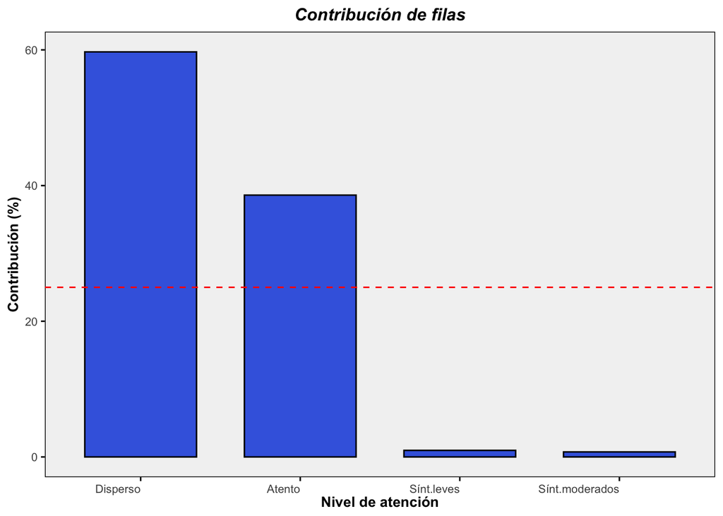

```r
# Contribución de filas y columnas al eje 1
fviz_contrib(atencion.ac,choice="row",axes=1, fill="royalblue",color ="black")+ theme(axis.text.x = element_text(angle=0)) + theme + labs(title = 'Contribución de filas',  x = 'Nivel de atención', y = 'Contribución (%)')+theme(panel.background = element_rect(fill = "grey95"))
```

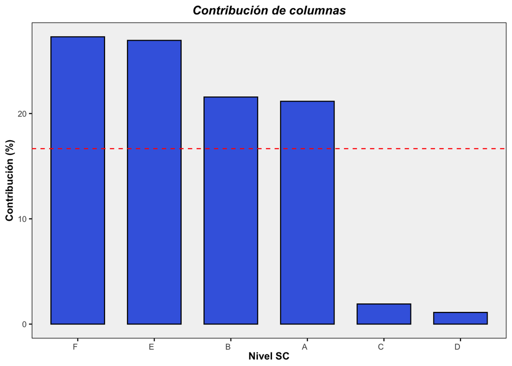

```r
fviz_contrib(atencion.ac,choice="col",axes=1, fill="royalblue",color ="black")+
 theme(axis.text.x = element_text(angle=0)) + theme + labs(title = 'Contribución de columnas',  x = 'Nivel SC', y = 'Contribución (%)')+theme(panel.background = element_rect(fill = "grey95"))
```

### Biplot simétrico

*OJO con la compatibilidad de coordenadas filas - columnas y las distancias calculadas. No se pueden analizar distancias entre categorías de fila y columna en un biplot simétrico. Las comparaciones son entre puntos fila o entre puntos columna, por separado.*

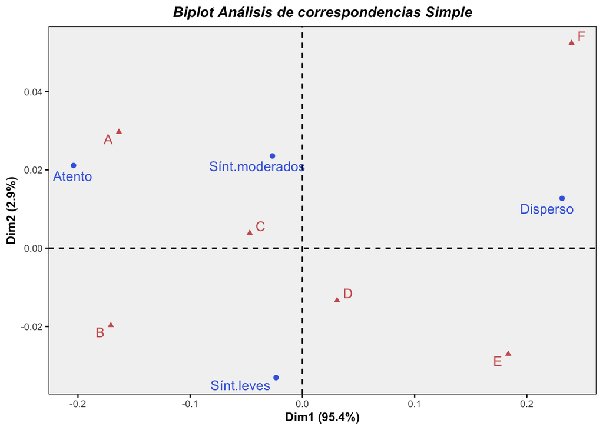

```r
fviz_ca_biplot( atencion.ac , repel  =TRUE, col.row="royalblue",col.col="indianred") + labs(title='Biplot Análisis de correspondencias Simple')+
theme+theme(panel.background = element_rect(fill = "grey95"))
```

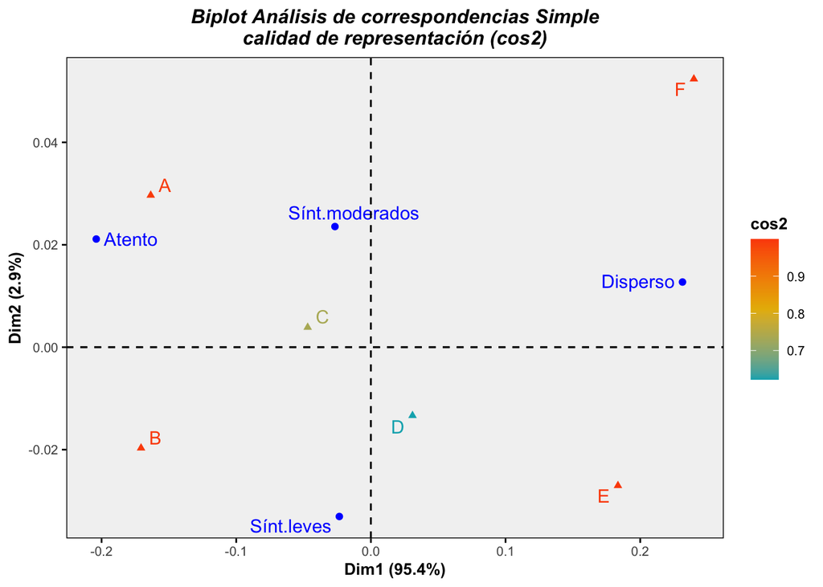

```r
fviz_ca_biplot( atencion.ac , repel  =TRUE, col.row="blue",col.col="cos2",gradient.cols = c("#00AFBB", "#E7B800", "#FC4E07")) + labs(title='Biplot Análisis de correspondencias Simple\ncalidad de representación (cos2)')+
theme+theme(panel.background = element_rect(fill = "grey95"))
```

Análisis de porcentaje de inercia explicada en cada dimensión

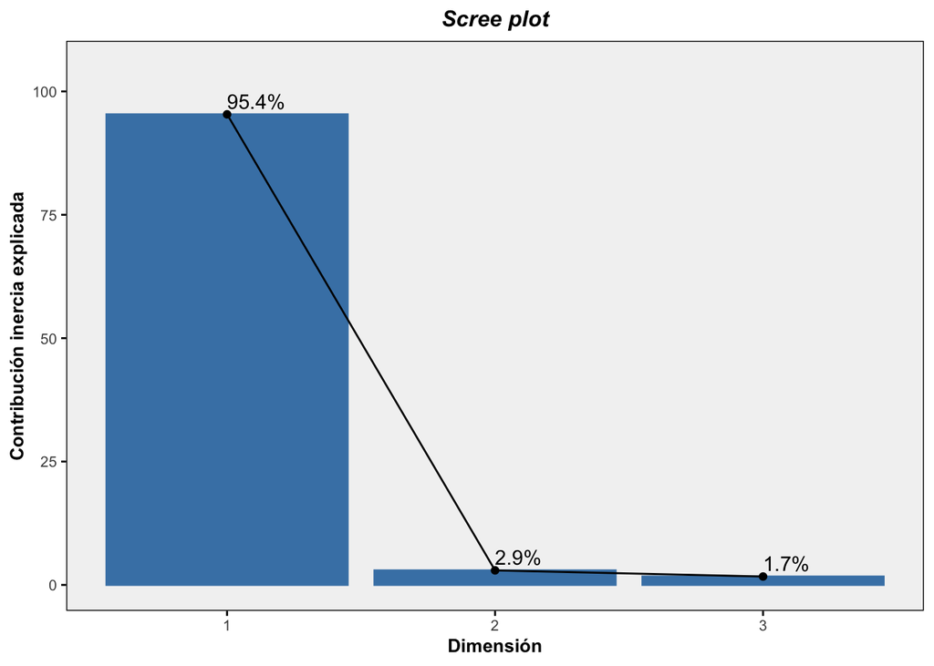

```r
fviz_screeplot(atencion.ac, addlabels = TRUE, ylim = c(0, 105))+
 theme(axis.text.x = element_text(angle=0)) + theme + labs(title = 'Scree plot',  x = 'Dimensión', y = 'Contribución inercia explicada')+theme(panel.background = element_rect(fill = "grey95"))
```

Coordenadas de puntos en nuevas dimensiones

```r
#coordenadas de filas y columnas
atencion.ac$row$coord
```

```
##                      Dim 1       Dim 2       Dim 3
## Atento         -0.20395493  0.02112209 -0.02353015
## Sínt.leves     -0.02343772 -0.03305525  0.00217072
## Sínt.moderados -0.02668982  0.02355937  0.03198258
## Disperso        0.23138980  0.01272728 -0.01348955
```

```r
atencion.ac$col$coord
```

```
##         Dim 1        Dim 2        Dim 3
## A -0.16349769  0.029671185 -0.013402390
## B -0.17069569 -0.019687938  0.010695556
## C -0.04695099  0.003880552  0.028349857
## D  0.03089364 -0.013346950 -0.026242458
## E  0.18345155 -0.027023110  0.007537920
## F  0.23983410  0.052371522  0.005313128
```

```r
atencion.ac$eig #autovalores, inercia explicada
```

```
##         eigenvalue percentage of variance cumulative percentage of variance
## dim 1 0.0206815721              95.354319                          95.35432
## dim 2 0.0006390530               2.946413                          98.30073
## dim 3 0.0003685573               1.699268                         100.00000
```

Información contenida por fila/col (coordenadas, contribuciones, calidad de representación [cos2] e inercia)

```r
atencion.ac$row
```

```
## $coord
##                      Dim 1       Dim 2       Dim 3
## Atento         -0.20395493  0.02112209 -0.02353015
## Sínt.leves     -0.02343772 -0.03305525  0.00217072
## Sínt.moderados -0.02668982  0.02355937  0.03198258
## Disperso        0.23138980  0.01272728 -0.01348955
##
## $contrib
##                     Dim 1    Dim 2      Dim 3
## Atento         38.5925324 13.39539 28.8245793
## Sínt.leves      0.9661623 62.19378  0.4650565
## Sínt.moderados  0.7362306 18.56507 59.3236990
## Disperso       59.7050747  5.84576 11.3866651
##
## $cos2
##                    Dim 1       Dim 2       Dim 3
## Atento         0.9765288 0.010473466 0.012997691
## Sínt.leves     0.3335948 0.663543640 0.002861518
## Sínt.moderados 0.3110308 0.242348033 0.446621122
## Disperso       0.9936170 0.003006091 0.003376959
##
## $inertia
## [1] 0.0081733811 0.0005989828 0.0004895465 0.0124272719
```

### Análisis de residuos

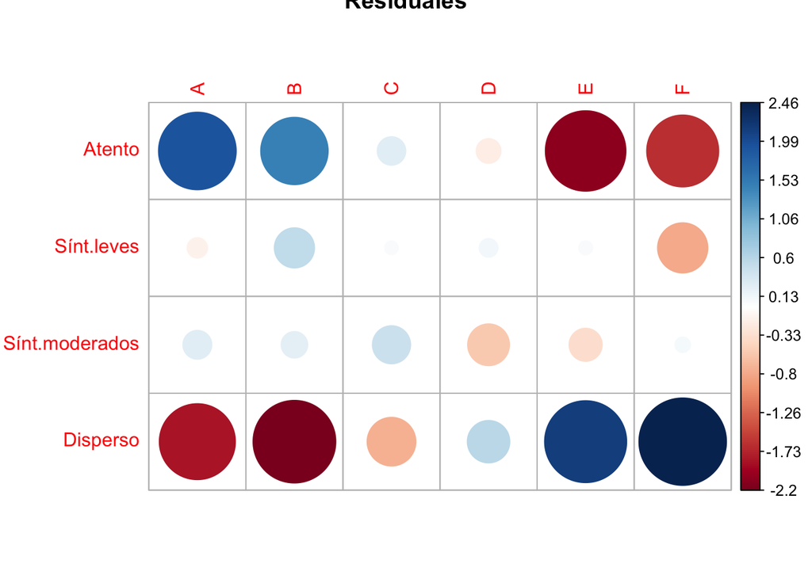

```r
# Análisis de residuos del test chi q
corrplot(chisq.test(base)$residuals , is.cor = FALSE, main='Residuales')
```

```r
base_completa <- as.data.frame(base)
base_completa$marginales <- rowSums(base_completa)
margin.table(base, 1)
```

```
##         Atento     Sínt.leves Sínt.moderados       Disperso
##            307            582            342            369
```

```r
base_completa <- rbind(base_completa,colSums(base_completa))
margin.table(base, 2)
```

```
##   A   B   C   D   E   F
## 262 245 287 384 265 157
```

```r
base_completa <- base_completa %>% mutate(perf_medioF= round(marginales/1600,2))
base_completa <- rbind(base_completa,round(colSums(base_completa)/1600,2))
rownames(base_completa)<-c("Atento","Sínt.leves","Sínt.moderados","Disperso","marginales2","perfil_medioC")
```

BASE DE DATOS OBSERVADA CON MARGINALES y frecuencias medias

```r
base_completa
```

|  | A | B | C | D | E | F | marginales | perf_medioF |
| --- | --- | --- | --- | --- | --- | --- | --- | --- |
| Atento | 64.00 | 57.00 | 57.00 | 72.00 | 36.00 | 21.0 | 307 | 0.19 |
| Sínt.leves | 94.00 | 94.00 | 105.00 | 141.00 | 97.00 | 51.0 | 582 | 0.36 |
| Sínt.moderados | 58.00 | 54.00 | 65.00 | 77.00 | 54.00 | 34.0 | 342 | 0.21 |
| Disperso | 46.00 | 40.00 | 60.00 | 94.00 | 78.00 | 51.0 | 369 | 0.23 |
| marginales2 | 262.00 | 245.00 | 287.00 | 384.00 | 265.00 | 157.0 | 1600 | 1.00 |
| perfil_medioC | 0.33 | 0.31 | 0.36 | 0.48 | 0.33 | 0.2 | 2 | 0.00 |

BASE DE DATOS ESPERADA

```r
round(ExpFreq(base, freq='abs'),0)
```

```
##                 A  B   C   D  E  F
## Atento         50 47  55  74 51 30
## Sínt.leves     95 89 104 140 96 57
## Sínt.moderados 56 52  61  82 57 34
## Disperso       60 57  66  89 61 36
```

```r
#round(ExpFreq(base, freq='rel'),2)
```

## 2) Ejemplo 2

### Cargo datos

*Responsabilidad de tareas del hogar utilizando base de datos de R*

```r
data(housetasks)
housetasks
```

|  | Wife | Alternating | Husband | Jointly |
| --- | --- | --- | --- | --- |
| Laundry | 156 | 14 | 2 | 4 |
| Main_meal | 124 | 20 | 5 | 4 |
| Dinner | 77 | 11 | 7 | 13 |
| Breakfeast | 82 | 36 | 15 | 7 |
| Tidying | 53 | 11 | 1 | 57 |
| Dishes | 32 | 24 | 4 | 53 |
| Shopping | 33 | 23 | 9 | 55 |
| Official | 12 | 46 | 23 | 15 |
| Driving | 10 | 51 | 75 | 3 |
| Finances | 13 | 13 | 21 | 66 |

[output cut: 3 more lines]

### Test de independencia Chi cuadrado

```r
# Test de independencia Chi-cuadrado
chisq.test(housetasks)
```

```
##
##  Pearson's Chi-squared test
##
## data:  housetasks
## X-squared = 1944.5, df = 36, p-value < 2.2e-16
```

Representación gráfica de valores absolutos de la tabla

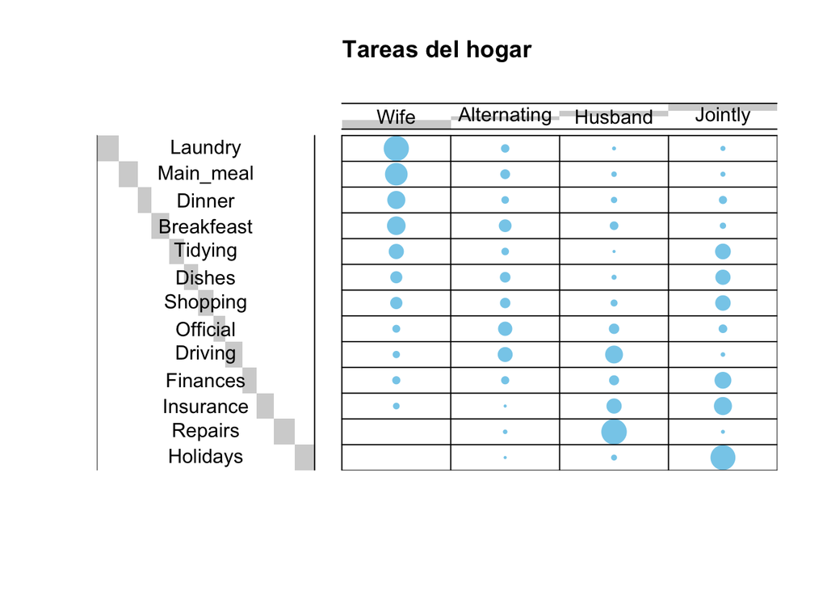

```r
dt <- as.table(as.matrix(housetasks))
balloonplot(t(dt), main ="Tareas del hogar", xlab ="", ylab="",
            label = FALSE, show.margins = FALSE)
```

### Análisis de correspondencias simple

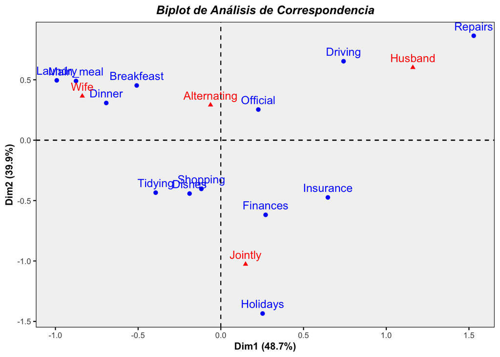

```r
house.ca <- CA(housetasks, graph = FALSE)

# Análisis de correspondencias de filas y columnas en simultáneo
fviz_ca_biplot(house.ca) +
 theme(axis.text.x = element_text(angle=0)) + theme + labs(title = 'Biplot de Análisis de Correspondencia')+theme(panel.background = element_rect(fill = "grey95"))
```

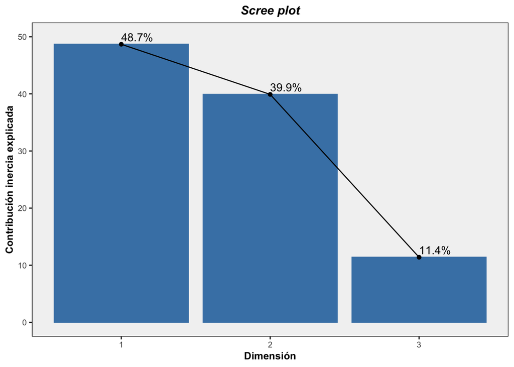

```r
fviz_screeplot(house.ca, addlabels = TRUE, ylim = c(0, 50))+
 theme(axis.text.x = element_text(angle=0)) + theme + labs(title = 'Scree plot',  x = 'Dimensión', y = 'Contribución inercia explicada')+theme(panel.background = element_rect(fill = "grey95"))
```

```r
#fviz_ca_row(house.ca) #filas
#fviz_ca_col(house.ca) #columnas

house.ca$row$coord #cos2/contrib/intertia
```

```
##                 Dim 1      Dim 2       Dim 3
## Laundry    -0.9918368  0.4953220 -0.31672897
## Main_meal  -0.8755855  0.4901092 -0.16406487
## Dinner     -0.6925740  0.3081043 -0.20741377
## Breakfeast -0.5086002  0.4528038  0.22040453
## Tidying    -0.3938084 -0.4343444 -0.09421375
## Dishes     -0.1889641 -0.4419662  0.26694926
## Shopping   -0.1176813 -0.4033171  0.20261512
## Official    0.2266324  0.2536132  0.92336416
## Driving     0.7417696  0.6534143  0.54445849
## Finances    0.2707669 -0.6178684  0.03479681
## Insurance   0.6470759 -0.4737832 -0.28936051
## Repairs     1.5287787  0.8642647 -0.47208778
## Holidays    0.2524863 -1.4350066 -0.12958665
```

```r
house.ca$col$coord #cos2/contrib/intertia
```

```
##                   Dim 1      Dim 2       Dim 3
## Wife        -0.83762154  0.3652207 -0.19991139
## Alternating -0.06218462  0.2915938  0.84858939
## Husband      1.16091847  0.6019199 -0.18885924
## Jointly      0.14942609 -1.0265791 -0.04644302
```

## 2) Ejemplo 3

### Cargo datos

*Relación de edad al delinquir y el año (base de datos del paquete logmult)*

```r
data("criminal", package = "logmult")
criminal
```

```
##       Age
## Year    15  16  17  18  19
##   1955 141 285 320 441 427
##   1956 144 292 342 441 396
##   1957 196 380 424 462 427
##   1958 212 424 399 442 430
```

### Test de independencia Chi-cuadrado

```r
# Test de independencia Chi-cuadrado
chisq.test(criminal)
```

```
##
##  Pearson's Chi-squared test
##
## data:  criminal
## X-squared = 38.41, df = 12, p-value = 0.0001315
```

Representación gráfica de valores absolutos

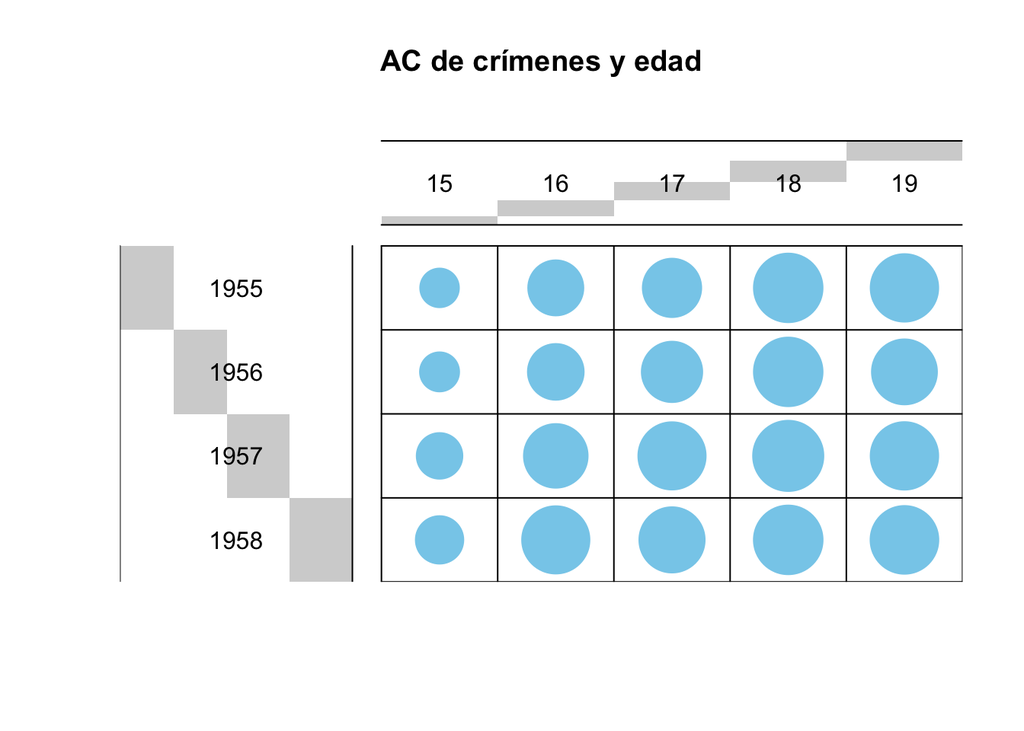

```r
dtc <- as.table(as.matrix(criminal))
balloonplot(t(dtc), main ="AC de crímenes y edad", xlab ="", ylab="",
            label = FALSE, show.margins = FALSE)
```

### Análisis de correspondencias simple

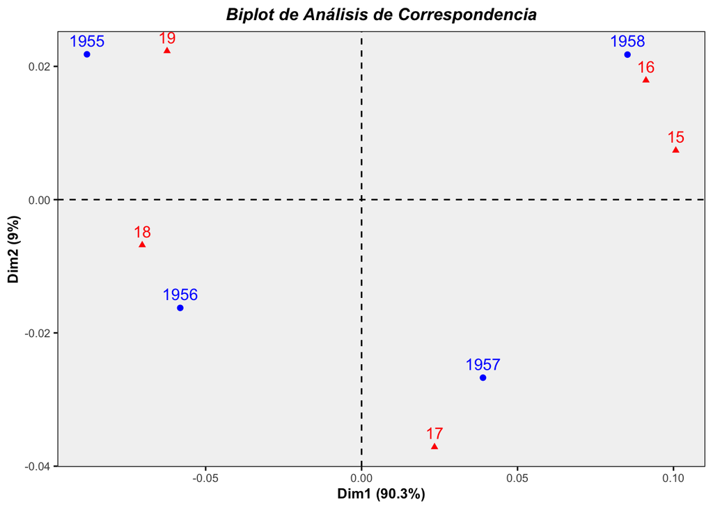

```r
criminal.ca <- CA(criminal, graph = FALSE)

# Análisis de correspondencias de filas y columnas en simultáneo
fviz_ca_biplot(criminal.ca) +
 theme(axis.text.x = element_text(angle=0)) + theme + labs(title = 'Biplot de Análisis de Correspondencia')+theme(panel.background = element_rect(fill = "grey95"))
```

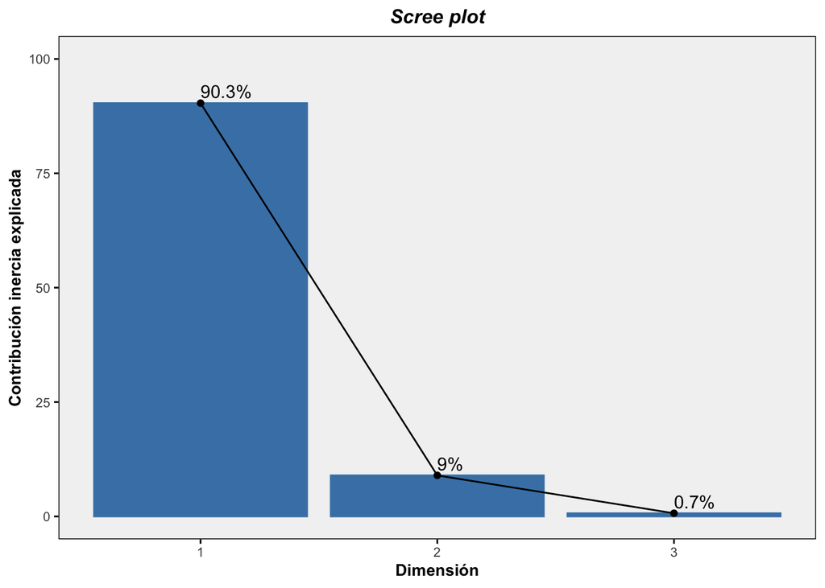

```r
fviz_screeplot(criminal.ca, addlabels = TRUE, ylim = c(0, 100))+
 theme(axis.text.x = element_text(angle=0)) + theme + labs(title = 'Scree plot',  x = 'Dimensión', y = 'Contribución inercia explicada')+theme(panel.background = element_rect(fill = "grey95"))
```

```r
#fviz_ca_row(criminal.ca) #filas
#fviz_ca_col(criminal.ca) #columnas

criminal.ca$row$coord #cos2/contrib/intertia
```

```
##            Dim 1       Dim 2        Dim 3
## 1955 -0.08806720  0.02181058  0.005540742
## 1956 -0.05815998 -0.01624531 -0.008964269
## 1957  0.03891307 -0.02672033  0.006012588
## 1958  0.08524490  0.02176644 -0.003053614
```

```r
criminal.ca$col$coord #cos2/contrib/intertia
```

```
##          Dim 1        Dim 2        Dim 3
## 15  0.10073800  0.007379498  0.005045408
## 16  0.09117251  0.017903878 -0.005702433
## 17  0.02337578 -0.037126625  0.004185445
## 18 -0.07034778 -0.006818980 -0.007438511
## 19 -0.06237653  0.022305053  0.006814516
```